# Site fidelity analysis

Marie Gilbertson

2025-02-12

# Introduction

In this report, I’ll demonstrate inter- and intra-annual site fidelity analyses. Site fidelity is quantified based on the Bhattacharyya coefficient between two home ranges: either ranges from the same season but different years (interannual), or ranges between subsequent seasons in the same year (intra-annual).

Note: Home ranges and Bhattacharyya coefficients are calculated using continuous time movement modeling from the *ctmm* package. Instructions and code for this method are thoroughly documented in the literature, and the code we used is not unique. We recommend interested users review [Silva et al 2021, *Methods in Ecology and Evolution*](https://doi.org/10.1111/2041-210X.13786) in order to apply CTMM methods to their own data. The specific function used to calculate Bhattacharyya coefficients is *overlap()*.

For this report, we’ll start by loading the packages we’ll need. I also always set my seed as standard practice (this makes randomization reproducible).

```r
##### Clear Environment #####
remove(list=ls())


#### set seed ####
set.seed(3571)

#### load libraries ####
library(move)
library(ggplot2)
library(ctmm)
library(lme4)
library(lmerTest)
library(glmmTMB)
library(plyr)
library(dplyr)
library(MetBrewer)
library(ggpubr)
library(lubridate)
library(DHARMa)
```

# Interannual site fidelity

We’ll start with interannual site fidelity. First, we’ll load and preview interannual site fidelity data; note that dispersal events have already been noted in the data, but we still need to remove them.

```r
### load and tidy up data ###
inter <- get(load("../Project_data/site_fidelity_interannual.Rdata"))
mod.dat <- inter[inter$disp=="no.disp",]
mod.dat$season <- factor(mod.dat$season, levels = c("fa", "pf", "br", "nb")) # re-level for correct order
mod.dat <- mod.dat[!is.na(mod.dat$age0),] # remove unknown ages

### preview ###
head(mod.dat)
```

```
##     id season year0 year1    sex age0        ba  ud.area0  ud.area1    disp
## 1 5000     fa  2017  2018 Female    6 0.6065396 0.8830120 0.5213984 no.disp
## 2 5004     fa  2017  2018 Female    7 0.8427427 0.2304049 0.1717509 no.disp
## 3 5006     nb  2017  2018 Female    5 0.9804812 1.9645674 1.8148893 no.disp
## 4 5006     fa  2017  2018 Female    6 0.9717624 1.2226526 1.2321036 no.disp
## 5 5016     fa  2017  2018 Female    3 0.9514148 0.3324414 0.3585271 no.disp
## 6 5022     fa  2017  2018 Female    1 0.9276771 0.3483023 0.3983051 no.disp
```

From the preview, we can see that our data is structured with columns for:

1. id = individual ID
2. season = the season of the home ranges being compared for site fidelity
3. year0 = the year of the first home range
4. year1 = the year of the second home range
5. sex = deer sex
6. age0 = age (integer) at the time of the first home range
7. ba = Bhattacharyya coefficient
8. ud.area0 = area (km^2) of the first home range
9. ud.area1 = area (km^2) of the second home range
10. disp = did a dispersal occur between the first and second home range?

Let’s view the distribution of the data.

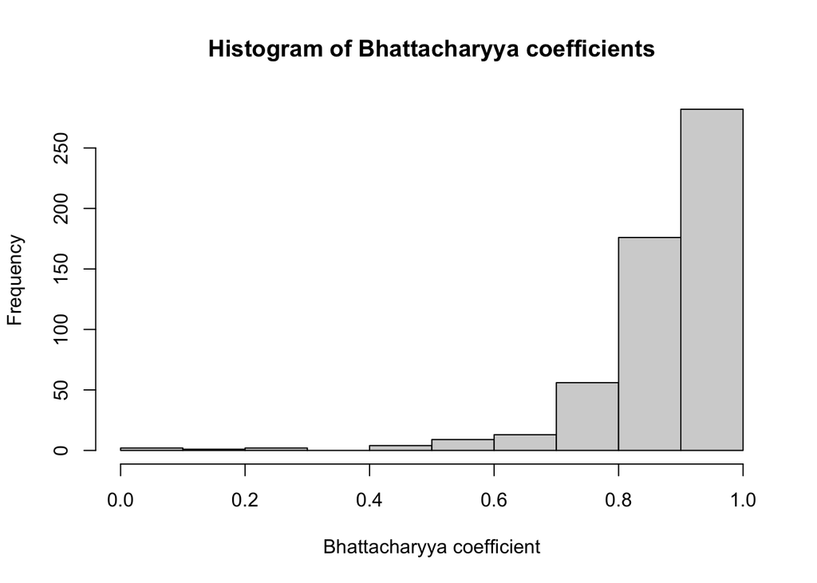

```r
hist(mod.dat$ba, main = "Histogram of Bhattacharyya coefficients", xlab = "Bhattacharyya coefficient")
```

We can see that Bhattacharyya coefficient values are limited to between 0 and 1; this necessitates modeling using Beta regression.

### Interannual Beta regression

We’ll prep our data, and then use the *glmmTMB* package to fit Beta regressions to our interannual site fidelity observations. Predictors in our models will include age, sex, season, and the absolute difference between the two home ranges (to control for site fidelity changes resulting simply from variation in home range size). We’ll also include random intercepts for individuals. Firstly, we’ll want to scale and center our continuous predictors.

```r
mod.dat$abs.diff <- abs(mod.dat$ud.area1 - mod.dat$ud.area0)
mod.dat$abs.diff.sc <- scale(mod.dat$abs.diff)
mod.dat$age0.sc <- scale(mod.dat$age0)
```

Next, we’ll split our data into training and testing data.

```r
set.seed(546516)
train.ids <- sample(1:nrow(mod.dat), size = floor(0.9*nrow(mod.dat)), replace = F)
test.ids <- seq(1:nrow(mod.dat))[!seq(1:nrow(mod.dat)) %in% train.ids]
train <- mod.dat[train.ids,]
test <- mod.dat[test.ids,]
```

Now we can fit a set of candidate models to our training data. Note that we are including models for the dispersion parameter.

```r
tm0 <- glmmTMB(ba ~ season + (1|id), dispformula = ~ season + sex, train, family=beta_family(link="logit"))

tm1 <- glmmTMB(ba ~ season + sex + age0.sc + (1|id), dispformula = ~ season + sex, train, family=beta_family(link="logit"))

tm2 <- glmmTMB(ba ~ season + age0.sc + sex + abs.diff.sc + (1|id), dispformula = ~ season + sex + as.factor(year0), train, family=beta_family(link="logit"))

tm3 <- glmmTMB(ba ~ season + sex + age0.sc + abs.diff.sc + (1|id), dispformula = ~ season + sex + abs.diff.sc, train, family=beta_family(link="logit"))
```

Let’s compare AIC values for our models.

```r
aics <- AIC(tm0, tm1, tm2, tm3)
aics[order(aics$AIC),]
```

```
##     df       AIC
## tm2 17 -1185.231
## tm3 14 -1173.660
## tm1 12 -1125.329
## tm0 10 -1105.835
```

It looks like our best supported model is “tm2,” but let’s review simulated residuals using the *DHARMa* package.

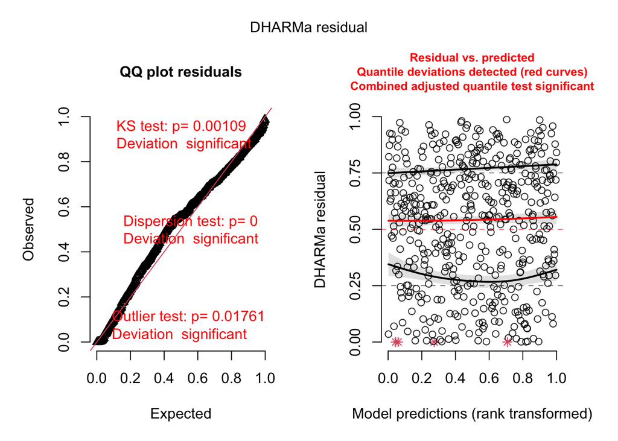

```r
top.mod <- tm2

sim_res <- DHARMa::simulateResiduals(top.mod, 1000, re.form = NULL)
plot(sim_res)
```

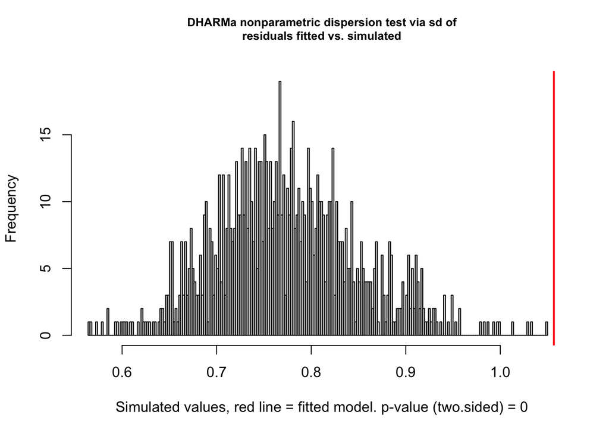

```
##
##  DHARMa nonparametric dispersion test via sd of residuals fitted vs.
##  simulated
##
## data:  simulationOutput
## dispersion = 1.3661, p-value < 2.2e-16
## alternative hypothesis: two.sided
```

```r
DHARMa::testDispersion(sim_res)
```

These results aren’t great. Let’s predict our response variable for our hold-out test data, and compare that to the observations.

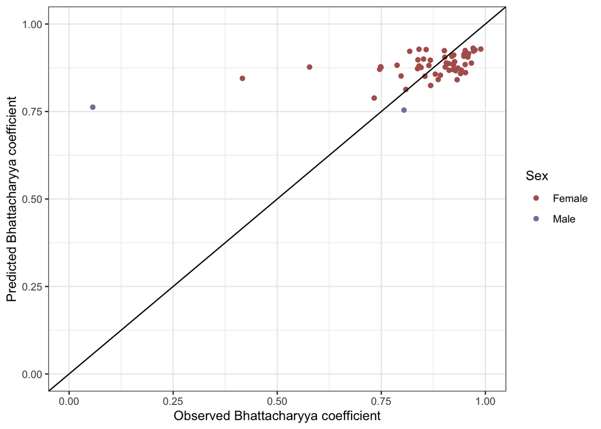

```r
test$predicted <- predict(top.mod, newdata = test, type = "response", allow.new.levels = T)
ggplot(test, aes(x = ba, y = predicted)) +
  geom_point(aes(colour = sex)) +
  scale_color_manual(values = met.brewer("Cassatt1", 4)[c(1,4)], name = "Sex") +
  geom_abline(slope = 1) +
  ylim(0,1) + xlim(0,1) +
  xlab("Observed Bhattacharyya coefficient") + ylab("Predicted Bhattacharyya coefficient") +
  theme_bw()
```

Again, these results aren’t great. I will say that a lot of other trouble shooting went on in the fitting of these models. As reported in the manuscript, it may simply be that beta regression is not ideal for the Bhattacharyya coefficient data.

Let’s take a look at our model results - interpreting them with some caution - and see if some non-parametric tests support our overall conclusions.

```r
summary(top.mod)
```

```
##  Family: beta  ( logit )
## Formula:          ba ~ season + age0.sc + sex + abs.diff.sc + (1 | id)
## Dispersion:          ~season + sex + as.factor(year0)
## Data: train
##
##      AIC      BIC   logLik deviance df.resid
##  -1185.2  -1113.9    609.6  -1219.2      473
##
## Random effects:
##
## Conditional model:
##  Groups Name        Variance  Std.Dev.
##  id     (Intercept) 1.163e-07 0.000341
## Number of obs: 490, groups:  id, 172
##
## Conditional model:
##             Estimate Std. Error z value Pr(>|z|)
## (Intercept)  1.84629    0.06044  30.548  < 2e-16 ***
## seasonpf    -0.03247    0.09473  -0.343  0.73178
## seasonbr     0.25510    0.09954   2.563  0.01038 *
## seasonnb     0.48924    0.08727   5.606 2.07e-08 ***
## age0.sc     -0.07070    0.03098  -2.282  0.02248 *
## sexMale     -0.67083    0.21362  -3.140  0.00169 **
## abs.diff.sc -0.24909    0.02909  -8.562  < 2e-16 ***
## ---
## Signif. codes:  0 '***' 0.001 '**' 0.01 '*' 0.05 '.' 0.1 ' ' 1
##
## Dispersion model:
##                       Estimate Std. Error z value Pr(>|z|)
## (Intercept)           2.949822   0.240102  12.286  < 2e-16 ***
## seasonpf              0.110538   0.194091   0.570 0.569006
## seasonbr              0.108665   0.188973   0.575 0.565273
## seasonnb              0.795400   0.214114   3.715 0.000203 ***
## sexMale              -1.836831   0.320895  -5.724 1.04e-08 ***
## as.factor(year0)2018  0.655908   0.454659   1.443 0.149123
## as.factor(year0)2019  0.009484   0.259110   0.037 0.970801
## as.factor(year0)2020 -0.459957   0.255412  -1.801 0.071727 .
## as.factor(year0)2021 -0.854860   0.331614  -2.578 0.009941 **
## ---
## Signif. codes:  0 '***' 0.001 '**' 0.01 '*' 0.05 '.' 0.1 ' ' 1
```

```r
### non-parametric tests ###
kruskal.test(ba ~ season, data = mod.dat)
```

```
##
##  Kruskal-Wallis rank sum test
##
## data:  ba by season
## Kruskal-Wallis chi-squared = 24.684, df = 3, p-value = 1.797e-05
```

```r
wilcox.test(ba ~ sex, data = mod.dat)
```

```
##
##  Wilcoxon rank sum test with continuity correction
##
## data:  ba by sex
## W = 12302, p-value = 1.108e-05
## alternative hypothesis: true location shift is not equal to 0
```

```r
wilcox.test(ba ~ sex, data = mod.dat[mod.dat$ba>0.15,]) # sex effect not solely due to the few males with very low BA (see data figure below)
```

```
##
##  Wilcoxon rank sum test with continuity correction
##
## data:  ba by sex
## W = 10766, p-value = 0.0002147
## alternative hypothesis: true location shift is not equal to 0
```

Despite our dodgy model checking, we have pretty solid support for significant relationships between interannual side fidelity and both season and sex. Let’s plot the data (included in the manuscript) to see these relationships first-hand.

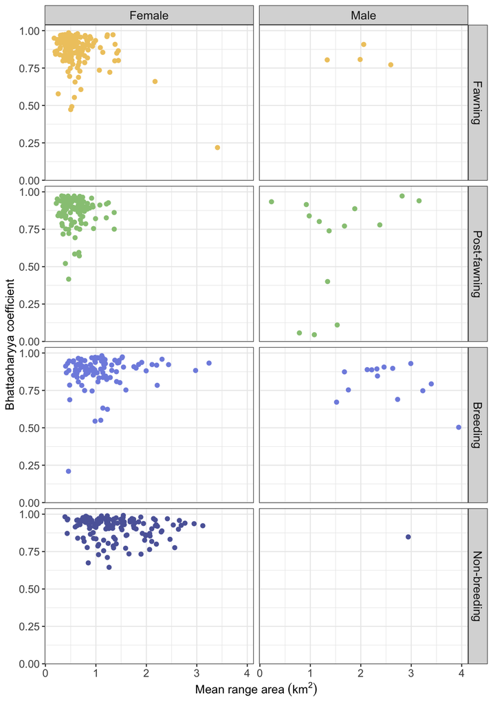

```r
mod.dat$season <- factor(mod.dat$season, levels = c("fa", "pf", "br", "nb")) # re-level so they plot in order
season.pal <- met.brewer("Derain", n= 4)
season.labs <- c("Fawning", "Post-fawning", "Breeding", "Non-breeding")
names(season.labs) <- c("fa", "pf", "br", "nb")
mod.dat$mean.area <- (mod.dat$ud.area0 + mod.dat$ud.area1)/2
ggplot(mod.dat) +
  geom_point(aes(x = mean.area, y = ba, colour = season), size = 1.8) +
  scale_colour_manual(values = season.pal) +
  facet_grid(season~sex, labeller = labeller(season = season.labs)) +
  labs(x = bquote('Mean range area'~(km^2)), y = "Bhattacharyya coefficient") +
  theme_bw() +
  theme(legend.position = "none", axis.title = element_text(size = 12), axis.text = element_text(size = 11), strip.text = element_text(size = 12))
```

# Intra-annual site fidelity

We’ll now repeat the same basic analysis for intra-annual site fidelity. In this case, we have quantified site fidelity as the Bhattacharyya coefficient between consecutive seasons in the same year. As with interannual site fidelity, we’ll start by loading and previewing our data.

```r
intra <- get(load("../Project_data/site_fidelity_intraannual.Rdata"))

intra$season01 <- factor(intra$season01, levels = c("fa_pf", "pf_br", "br_nb", "nb_fa"))
mod.dat <- intra[intra$disp=="no.disp",]


### preview
head(mod.dat)
```

```
##     id season0 season1 start1 end1 start2 end2 year.ssf    sex age0        ba
## 1 5000      fa      pf   2017 2017   2017 2017     2017 Female    6 0.9233078
## 2 5002      fa      pf   2017 2017   2017 2017     2017   Male    1 0.8887687
## 3 5004      fa      pf   2017 2017   2017 2017     2017 Female    7 0.8893280
## 4 5004      nb      fa   2017 2018   2018 2018     2017 Female    7 0.8533917
## 5 5006      nb      fa   2017 2017   2017 2017     2016 Female    5 0.7758071
## 6 5006      fa      pf   2017 2017   2017 2017     2017 Female    6 0.8922348
##    ud.area0  ud.area1 season01   area.diff abs.area.diff    disp
## 1 0.8827916 0.7888523    fa_pf -0.09393930    0.09393930 no.disp
## 2 1.5146709 0.8273645    fa_pf -0.68730636    0.68730636 no.disp
## 3 0.2303899 0.2020544    fa_pf -0.02833552    0.02833552 no.disp
## 4 0.3892206 0.1717509    nb_fa -0.21746965    0.21746965 no.disp
## 5 1.9647674 1.2225947    nb_fa -0.74217263    0.74217263 no.disp
## 6 1.2225947 1.0646385    fa_pf -0.15795623    0.15795623 no.disp
```

From the data preview, we can see that our data is structured into the following columns:  
1. id = individual ID  
2. season0 = season for the first home range being compared  
3. season1 = season for the second home range  
4. start1 = starting year of data coverage for the first home range (the non-breeding season starts in Dec and ends in after the new year)  
5. end1 = ending year of data coverage for the first home range  
6. start2 = starting year of data coverage for the second home range  
7. end2 = ending year of data coverage for the second home range  
8. year.ssf = year of the movement data, as represented in iSSF analysis  
9. sex = deer sex  
10. age0 = deer age at time of the first home range  
11. ba = Bhattacharyya coefficient  
12. ud.area0 = area (km^2) of the first home range  
13. ud.area1 = area (km^2) of the second home range  
14. season01 = combination of the start and end seasons  
15. area.diff = difference in area between the two ranges  
16. abs.area.diff = absolute value of the area difference  
17. disp = did a dispersal occur between the first and second ranges?

Let’s view the distribution of the site fidelity data.

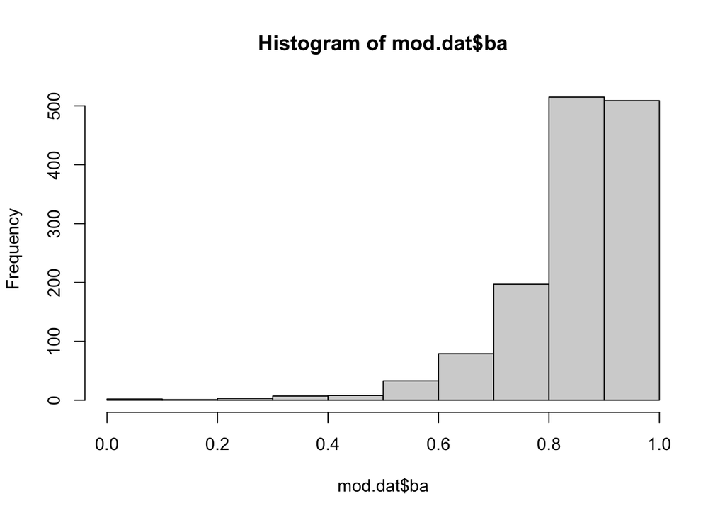

```r
hist(mod.dat$ba)
```

Again, because the Bhattacharyya coefficient is limited to between 0 and 1, we’ll use Beta regressions.

### Intra-annual Beta regression

As in interannual site fidelity analysis, we’ll prep our data, including scaling and centering our continuous predictors.

```r
mod.dat$ba[mod.dat$ba==0] <- 0.001 ## can try converting zeros to very small values to better accommodate the beta regression
mod.dat$abs.area.diff.sc <- scale(mod.dat$abs.area.diff)
mod.dat$age0.sc <- scale(mod.dat$age0)
```

Next, we’ll split our data into training and testing datasets.

```r
set.seed(3516)
train.ids <- sample(1:nrow(mod.dat), size = floor(0.9*nrow(mod.dat)), replace = F)
test.ids <- seq(1:nrow(mod.dat))[!seq(1:nrow(mod.dat)) %in% train.ids]
train <- mod.dat[train.ids,]
test <- mod.dat[test.ids,]
```

And now we can fit some candidate models to our training data.

```r
tm0a <- glmmTMB(ba ~ season01 + abs.area.diff.sc + sex + age0.sc + (1 + age0.sc|id), dispformula = ~ season01 + abs.area.diff.sc + sex + age0.sc, train, family=beta_family(link="logit"))

tm1a <- glmmTMB(ba ~ season01 * abs.area.diff.sc + sex + age0.sc + (1 + age0.sc|id), dispformula = ~ season01 + abs.area.diff.sc + sex + age0.sc, train, family=beta_family(link="logit"))

tm2a <- glmmTMB(ba ~ season01 + abs.area.diff.sc * sex + age0.sc + (1 + age0.sc|id), dispformula = ~ season01 + abs.area.diff.sc + sex + age0.sc, train, family=beta_family(link="logit"))

tm3a <- glmmTMB(ba ~ season01* sex + abs.area.diff.sc + age0.sc + (1 + age0.sc|id), dispformula = ~ season01* sex + abs.area.diff.sc  + age0.sc, train, family=beta_family(link="logit"))

tm4a <- glmmTMB(ba ~ season01* sex + abs.area.diff.sc + age0.sc*sex + (1 + age0.sc|id), dispformula = ~ season01 + sex + abs.area.diff.sc + age0.sc, train, family=beta_family(link="logit"))

tm5a <- glmmTMB(ba ~ season01* sex + abs.area.diff.sc + age0.sc*sex + (1 + age0.sc|id), dispformula = ~ season01 * sex + abs.area.diff.sc + age0.sc, train, family=beta_family(link="logit"))

tm6a <- glmmTMB(ba ~ season01* sex + age0.sc*sex + season01*age0.sc + abs.area.diff.sc + (1 + age0.sc|id), dispformula = ~ season01 + sex + abs.area.diff.sc + age0.sc, train, family=beta_family(link="logit"))
```

Let’s check out our AIC values for these models.

```r
aicsa <- AIC(tm0a, tm1a, tm2a, tm3a, tm4a, tm5a, tm6a)
aicsa <- aicsa[order(aicsa$AIC),]
aicsa$delta <- aicsa$AIC - aicsa$AIC[1]
aicsa
```

```
##      df       AIC      delta
## tm4a 21 -2784.153  0.0000000
## tm5a 24 -2784.040  0.1131738
## tm6a 24 -2782.250  1.9024383
## tm3a 23 -2779.610  4.5427821
## tm1a 20 -2761.527 22.6260154
## tm2a 18 -2757.566 26.5865972
## tm0a 17 -2755.862 28.2910474
```

It looks like model “tm4a” is best supported, but “tm5a” and “tm6a” are equivalent by a ∆2 AIC standard. Let’s check out our simulated residuals with the *DHARMa* package.

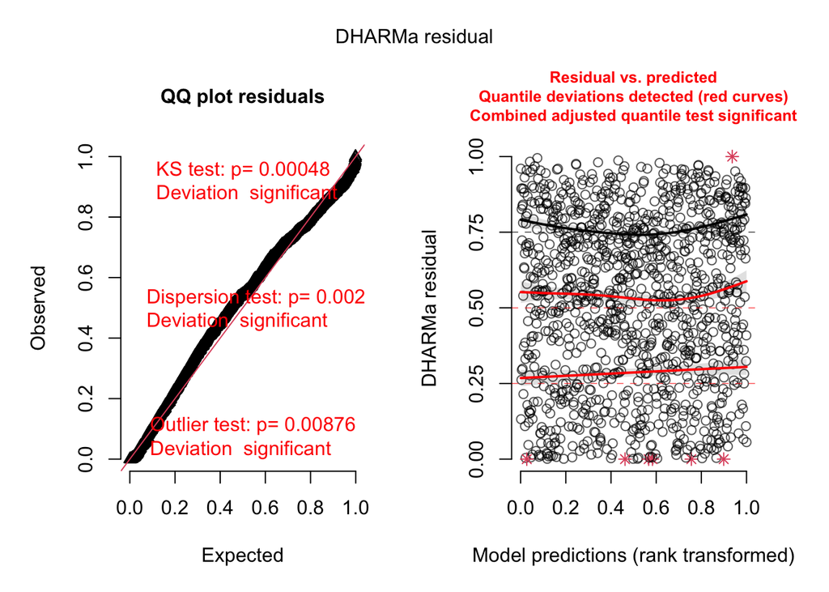

```r
top.mod <- tm4a
sim_res <- DHARMa::simulateResiduals(top.mod, 1000, re.form = NULL)
plot(sim_res)
```

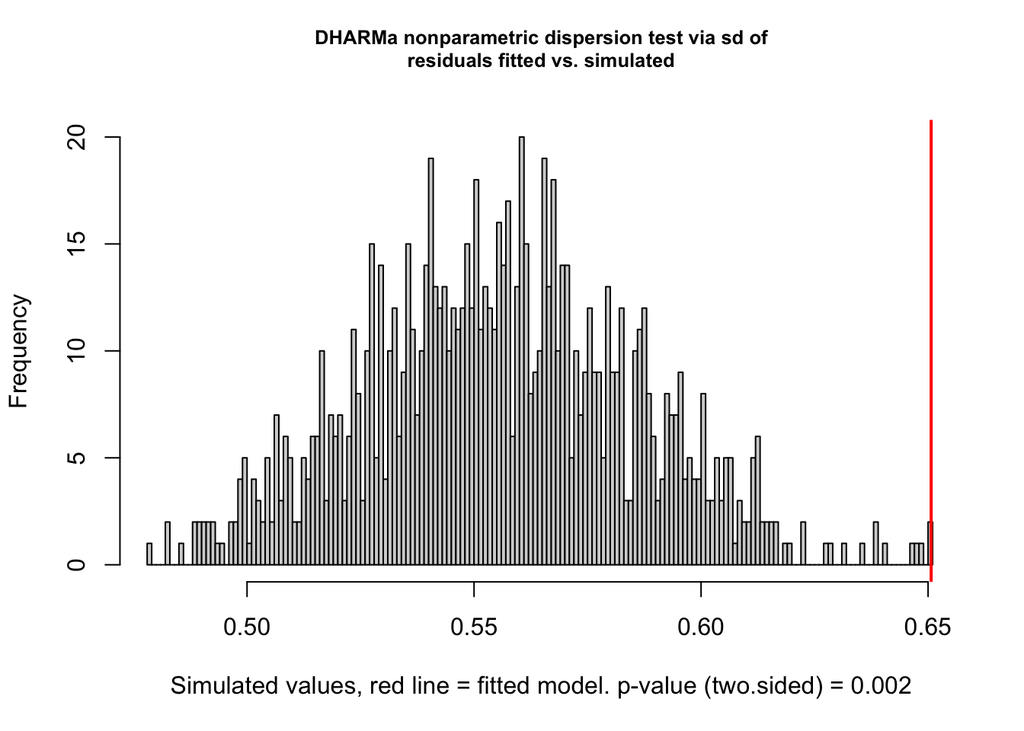

```
##
##  DHARMa nonparametric dispersion test via sd of residuals fitted vs.
##  simulated
##
## data:  simulationOutput
## dispersion = 1.1704, p-value = 0.002
## alternative hypothesis: two.sided
```

```r
DHARMa::testDispersion(sim_res)
```

As with interannual site fidelity, this looks pretty dodgy. Let’s check out predictions for our hold-out testing dataset.

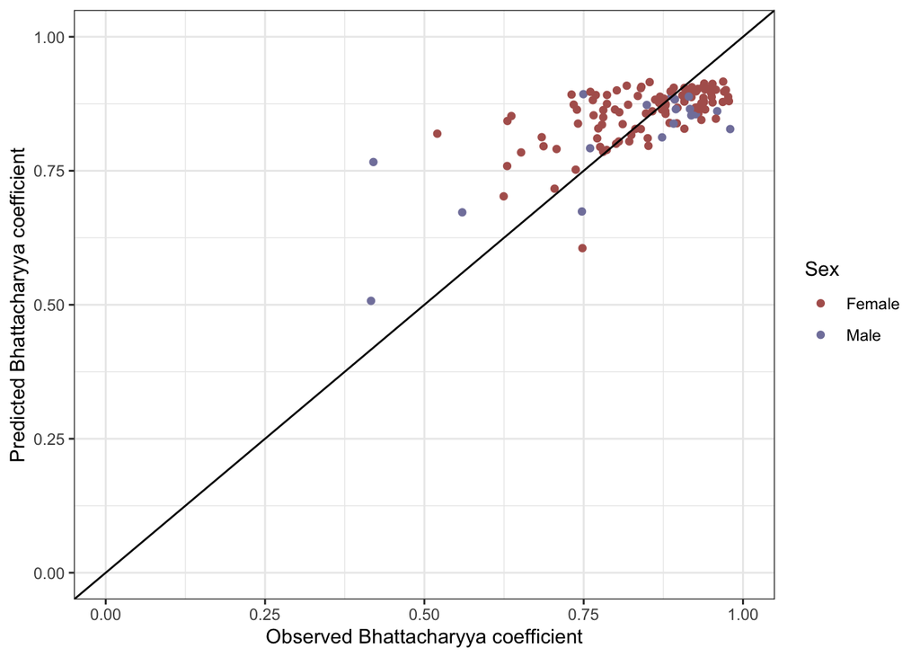

```r
test$predicted <- predict(top.mod, newdata = test, type = "response", allow.new.levels = T)
ggplot(test, aes(x = ba, y = predicted)) +
  geom_point(aes(colour = sex)) +
  scale_color_manual(values = met.brewer("Cassatt1", 4)[c(1,4)], name = "Sex") +
  geom_abline(slope = 1) +
  xlim(0,1) + ylim(0,1) +
  xlab("Observed Bhattacharyya coefficient") + ylab("Predicted Bhattacharyya coefficient") +
  theme_bw()
```

These predictions also don’t look outstanding, but - like interannual site fidelty - checking out the data itself supports some general conclusions. Again, it seems like Beta regression just doesn’t handle this response variable very well.

Our model results look like this:

```r
summary(top.mod)
```

```
##  Family: beta  ( logit )
## Formula:
## ba ~ season01 * sex + abs.area.diff.sc + age0.sc * sex + (1 +
##     age0.sc | id)
## Dispersion:          ~season01 + sex + abs.area.diff.sc + age0.sc
## Data: train
##
##      AIC      BIC   logLik deviance df.resid
##  -2784.2  -2678.4   1413.1  -2826.2     1117
##
## Random effects:
##
## Conditional model:
##  Groups Name        Variance Std.Dev. Corr
##  id     (Intercept) 0.032727 0.18091
##         age0.sc     0.006253 0.07908  -0.89
## Number of obs: 1138, groups:  id, 375
##
## Conditional model:
##                       Estimate Std. Error z value Pr(>|z|)
## (Intercept)            1.98873    0.03727   53.36  < 2e-16 ***
## season01pf_br         -0.28122    0.05416   -5.19 2.08e-07 ***
## season01br_nb          0.06711    0.05664    1.18 0.236073
## season01nb_fa         -0.48025    0.05323   -9.02  < 2e-16 ***
## sexMale                0.26976    0.21046    1.28 0.199911
## abs.area.diff.sc      -0.30052    0.01944  -15.46  < 2e-16 ***
## age0.sc               -0.05617    0.02226   -2.52 0.011627 *
## season01pf_br:sexMale -0.49841    0.13269   -3.76 0.000173 ***
## season01br_nb:sexMale -0.60160    0.26713   -2.25 0.024316 *
## season01nb_fa:sexMale  0.75983    0.19540    3.89 0.000101 ***
## sexMale:age0.sc        0.81897    0.30166    2.71 0.006629 **
## ---
## Signif. codes:  0 '***' 0.001 '**' 0.01 '*' 0.05 '.' 0.1 ' ' 1
##
## Dispersion model:
##                  Estimate Std. Error z value Pr(>|z|)
## (Intercept)       3.43070    0.08887   38.60  < 2e-16 ***
## season01pf_br    -0.59994    0.11634   -5.16 2.51e-07 ***
## season01br_nb    -0.00745    0.14441   -0.05   0.9589
## season01nb_fa    -0.13105    0.14030   -0.93   0.3503
## sexMale          -0.93096    0.13674   -6.81 9.87e-12 ***
## abs.area.diff.sc  0.11691    0.06071    1.93   0.0541 .
## age0.sc          -0.10676    0.05416   -1.97   0.0487 *
## ---
## Signif. codes:  0 '***' 0.001 '**' 0.01 '*' 0.05 '.' 0.1 ' ' 1
```

And let’s take a look at the data itself:

```r
season.pal <- met.brewer("Derain", n= 4)
sex.pal <-   met.brewer("Cassatt1", 4)[c(1, 4)]
mod.dat$season01 <- factor(mod.dat$season01, levels =  c("fa_pf", "pf_br", "br_nb", "nb_fa")) # re-level to make sure plots in the right order

## site fidelity by season
p <- ggplot(mod.dat) +
  geom_hline(yintercept = 1, linetype = "dashed", colour = "darkgrey") +
  geom_jitter(aes(x = season01, y = ba, colour = sex), position = position_jitterdodge(jitter.width = 0.1, dodge.width = 0.6), alpha = 0.4) +
  geom_boxplot(aes(x = season01, y = ba, colour = sex), fill = "transparent", width = 0.3, position = position_dodge(width = 0.6), outlier.shape = NA, linewidth = 0.7) +
  scale_colour_manual(values = sex.pal) +
  ylab("Bhattacharyya coefficient") + xlab("Season") +
  scale_x_discrete(labels = c("fa_pf" = "Fa-PF", "pf_br" = "PF-Br", "br_nb" = "Br-NB", "nb_fa" = "NB-Fa")) +
  theme_bw() +
  theme(axis.title = element_text(size = 12), axis.text = element_text(size = 11), plot.title = element_blank(),
        legend.position = "none")




## site fidelity by absolute difference in home range area
sn.labs <- data.frame(label = c("Fawning%->%`Post-fawning`", "`Post-fawning`%->%Breeding", "Breeding%->%`Non-breeding`", "`Non-breeding`%->%Fawning"),
                      season01 = c("fa_pf", "pf_br", "br_nb", "nb_fa"))
mod.dat <- left_join(mod.dat, sn.labs, by = "season01")
head(mod.dat)
```

```
##     id season0 season1 start1 end1 start2 end2 year.ssf    sex age0        ba
## 1 5000      fa      pf   2017 2017   2017 2017     2017 Female    6 0.9233078
## 2 5002      fa      pf   2017 2017   2017 2017     2017   Male    1 0.8887687
## 3 5004      fa      pf   2017 2017   2017 2017     2017 Female    7 0.8893280
## 4 5004      nb      fa   2017 2018   2018 2018     2017 Female    7 0.8533917
## 5 5006      nb      fa   2017 2017   2017 2017     2016 Female    5 0.7758071
## 6 5006      fa      pf   2017 2017   2017 2017     2017 Female    6 0.8922348
##    ud.area0  ud.area1 season01   area.diff abs.area.diff    disp
## 1 0.8827916 0.7888523    fa_pf -0.09393930    0.09393930 no.disp
## 2 1.5146709 0.8273645    fa_pf -0.68730636    0.68730636 no.disp
## 3 0.2303899 0.2020544    fa_pf -0.02833552    0.02833552 no.disp
## 4 0.3892206 0.1717509    nb_fa -0.21746965    0.21746965 no.disp
## 5 1.9647674 1.2225947    nb_fa -0.74217263    0.74217263 no.disp
## 6 1.2225947 1.0646385    fa_pf -0.15795623    0.15795623 no.disp
##   abs.area.diff.sc    age0.sc                     label
## 1       -0.7423386  0.9922353 Fawning%->%`Post-fawning`
## 2        0.2799757 -0.7221691 Fawning%->%`Post-fawning`
## 3       -0.8553676  1.3351162 Fawning%->%`Post-fawning`
## 4       -0.5295077  1.3351162 `Non-breeding`%->%Fawning
## 5        0.3745050  0.6493544 `Non-breeding`%->%Fawning
## 6       -0.6320436  0.9922353 Fawning%->%`Post-fawning`
```

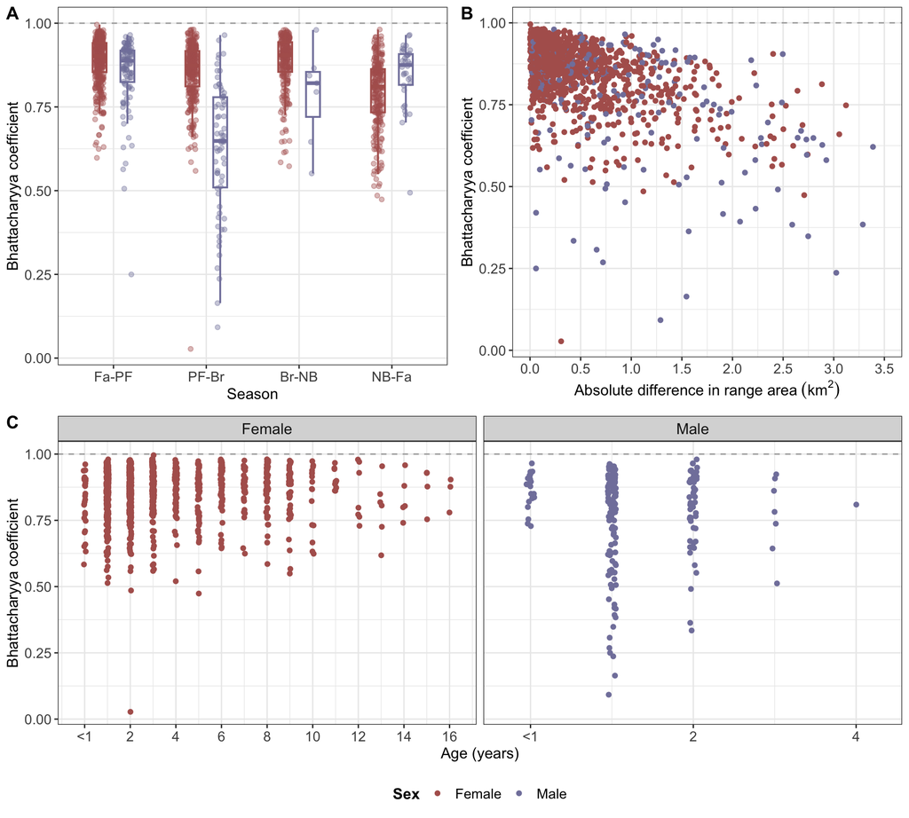

```r
mod.dat$label <- factor(mod.dat$label, levels =  c("Fawning%->%`Post-fawning`", "`Post-fawning`%->%Breeding", "Breeding%->%`Non-breeding`", "`Non-breeding`%->%Fawning"))

px <- pretty(mod.dat$abs.area.diff)
p2 <- ggplot(mod.dat) +
  geom_hline(yintercept = 1, linetype = "dashed", colour = "darkgrey") +
  geom_point(aes(x = abs.area.diff, y = ba, colour = sex)) +
  scale_colour_manual(values = sex.pal, name = "Sex") +
  ylab("Bhattacharyya coefficient") + xlab(bquote('Absolute difference in range area' ~(km^2))) +
  # facet_wrap(~label, labeller = label_parsed)+
  scale_x_continuous(limits = range(px), breaks = px) +
  theme_bw() +
  theme(axis.title = element_text(size = 12), axis.text = element_text(size = 11), plot.title = element_blank(),
        strip.text = element_text(size = 12), legend.title = element_text(size = 12, face = "bold"), legend.text = element_text(size = 11),
        legend.position = "none")

## site fidelity by age
p3 <- ggplot(mod.dat) +
  geom_hline(yintercept = 1, linetype = "dashed", colour = "darkgrey") +
  geom_jitter(aes(x = age0, y = ba, colour = sex), position = position_jitterdodge(jitter.width = 0.1, dodge.width = 0.6)) +
  scale_colour_manual(values = sex.pal, name = "Sex") +
  scale_x_continuous(breaks = seq(0, 17, by=2), labels = c("<1", 2, 4, 6, 8, 10, 12, 14, 16)) +
  ylab("Bhattacharyya coefficient") + xlab("Age (years)") +
  facet_wrap(~sex, scales = "free_x")+
  theme_bw() +
  theme(axis.title = element_text(size = 12), axis.text = element_text(size = 11), plot.title = element_blank(),
        strip.text = element_text(size = 12), legend.title = element_text(size = 12, face = "bold"), legend.text = element_text(size = 11),
        legend.position = "bottom")



## put them all together
p.12 <- ggarrange(p, p2, nrow = 1, labels = c("A", "B"))
p.123 <- ggarrange(p.12, p3, ncol = 1, labels = c("", "C"))
p.123
```